# VMS Initial Exploration

## Purpose

The goal of this analysis is to do some preliminary explorations and scratch work with the processed VMS data for the west coast Dungeness fishery. We will start with investigating broad trends, followed by trying to identify patterns in the space use of a couple of individual boats. We’ll do this with one year (2011, a strong year before the warm blob)

## Setup

```r
library(tidyverse)
library(sf)
library(here)
library(knitr)
library(extrafont)
library(rnaturalearth)
library(lubridate)
library(ggsci)

# ggplot theme
plot_theme <-   theme_minimal()+
  theme(text=element_text(family="Gill Sans MT",size=12,color="black"),
        legend.text = element_text(size=14),
        axis.title=element_text(family="sans",size=14,color="black"),
        axis.text=element_text(family="sans",size=8,color="black"),
        panel.grid.major = element_line(color="gray50",linetype=3))
theme_set(plot_theme)
```

### Import the data

```r
vms <- read_csv("C:/Users/owenr/Documents/postdocs/NOAA NRC/NWFSC work/VMS DATA CONFIDENTIAL/Processed Data/VMS/VMS_Outputs_wTARGET_10d_lookback_2011_final_cleaned_interpolated_regular.csv",col_types='dcTddccddTDdccccd')

glimpse(vms)
```

```
## Observations: 903,769
## Variables: 17
## $ Rec_ID               <dbl> 47948959, 47948959, 47948959, 47948959, 4...
## $ DOCNUM               <chr> "923632", "923632", "923632", "923632", "...
## $ UTCDATETIM           <dttm> 2011-01-27 09:56:00, 2011-01-27 10:56:00...
## $ LATITUDE             <dbl> 45.71720, 45.71350, 45.70970, 45.70596, 4...
## $ LONGITUDE            <dbl> -124.1390, -124.1450, -124.1470, -124.145...
## $ VESSEL_NAM           <chr> "Nicole", "Nicole", "Nicole", "Nicole", "...
## $ DECLARATIO           <chr> "269", "269", "269", "269", "269", "269",...
## $ X_COORD              <dbl> 411356.5, 410883.9, 410721.7, 410869.3, 4...
## $ Y_COORD              <dbl> 5063258, 5062854, 5062434, 5062016, 50551...
## $ westcoastdate        <dttm> 2011-01-27 01:56:00, 2011-01-27 02:56:00...
## $ westcoastdate_notime <date> 2011-01-27, 2011-01-27, 2011-01-27, 2011...
## $ avg_speed_recalc     <dbl> 0.1727069, 0.1250644, 0.1231495, 2.133578...
## $ TARGET               <chr> "DCRB", "DCRB", "DCRB", "DCRB", "DCRB", "...
## $ Port_Of_Landing      <chr> "AST", "AST", "AST", "AST", "AST", "AST",...
## $ TARGET_max           <chr> "DCRB", "DCRB", "DCRB", "DCRB", "DCRB", "...
## $ sensor               <chr> "unknown", "unknown", "unknown", "interpo...
## $ VMS_RECNO            <dbl> 20113583488, 20110587136, 20115431874, 20...
```

```r
paste('There are',length(unique(vms$VMS_RECNO)), 'VMS records in this cleaned and interpolated version of the data, representing',length(unique(vms$Rec_ID)),'trips and',length(unique(vms$DOCNUM)),'vessels.')
```

```
## [1] "There are 903769 VMS records in this cleaned and interpolated version of the data, representing 20363 trips and 751 vessels."
```

There are 903769 VMS records in this cleaned and interpolated version of the data, representing 20363 trips and 751 vessels.

## Descriptive Plots

We can count the number of VMS records and trips by vessel and by primary target species.

```r
vessel_target_n <- vms %>%
  count(DOCNUM,TARGET_max) %>%
  arrange(desc(n))
vessel_target_n %>%
  slice(1:50) %>%
  kable(col.names = c('Vessel','Target','VMS recs'))
```

| Vessel | Target | VMS recs |
| --- | --- | --- |
| CF9854KB | SSPN | 3997 |
| 251017 | USCU | 3456 |
| 252774 | RCRB | 3407 |
| CF6691KM | SCR1 | 3122 |
| WN1724NF | DCRB | 2982 |
| 693112 | RURC | 2916 |
| 589552 | PSHP | 2883 |
| 609556 | UHAG | 2734 |
| 1044097 | RCRB | 2720 |
| 274577 | UHAG | 2663 |
| 552616 | PSHP | 2529 |
| 521529 | PSHP | 2479 |
| 694038 | SABL | 2357 |
| 640718 | PSHP | 2300 |
| 981390 | PSHP | 2254 |
| 529532 | PSHP | 2198 |
| 645410 | PSHP | 2189 |
| 533885 | DCRB | 2187 |
| 598880 | PSHP | 2173 |
| 598974 | PSHP | 2156 |
| 605198 | DCRB | 2127 |
| 559907 | PSHP | 2092 |
| 1021713 | PSHP | 2076 |
| CF6936SG | CHL1 | 2052 |
| 517487 | PSHP | 2039 |
| 594793 | PSHP | 2026 |
| 1044140 | SPRW | 2015 |
| 936611 | PSHP | 1980 |
| CF2786SA | SABL | 1960 |
| 670913 | LOBS | 1946 |
| 570945 | DOVR | 1943 |
| 1037785 | DOVR | 1921 |
| 524554 | DCRB | 1918 |
| 515580 | DCRB | 1916 |
| 580135 | DCRB | 1910 |
| 942862 | PSHP | 1882 |
| 533394 | DCRB | 1872 |
| 913277 | PWHT | 1858 |
| 251864 | USCU | 1852 |
| 528154 | DCRB | 1800 |
| CF7581UF | LOBS | 1794 |
| 602145 | DCRB | 1786 |
| 589114 | PSHP | 1767 |
| 528154 | PSHP | 1761 |
| 560023 | USCU | 1759 |
| CF0298SU | SPRW | 1738 |
| 531055 | PSHP | 1735 |
| CF4476ET | RCRB | 1721 |
| 635397 | SABL | 1715 |
| 521196 | DCRB | 1704 |

```r
# For DCRB only, the top 50 vessels by number of VMS records
vessel_targ_n_dcrb <- vms %>%
  filter(TARGET_max=="DCRB") %>%
  count(DOCNUM,TARGET_max) %>%
  arrange(desc(n))
vessel_targ_n_dcrb %>%
  slice(1:50) %>%
  kable(col.names=c('Vessel','Target','VMS_recs'))
```

| Vessel | Target | VMS_recs |
| --- | --- | --- |
| WN1724NF | DCRB | 2982 |
| 533885 | DCRB | 2187 |
| 605198 | DCRB | 2127 |
| 524554 | DCRB | 1918 |
| 515580 | DCRB | 1916 |
| 580135 | DCRB | 1910 |
| 533394 | DCRB | 1872 |
| 528154 | DCRB | 1800 |
| 602145 | DCRB | 1786 |
| 521196 | DCRB | 1704 |
| 613483 | DCRB | 1677 |
| 507118 | DCRB | 1626 |
| 959096 | DCRB | 1575 |
| CF7109TB | DCRB | 1570 |
| 1193066 | DCRB | 1544 |
| 603201 | DCRB | 1540 |
| 595175 | DCRB | 1527 |
| 639209 | DCRB | 1507 |
| OR921ABG | DCRB | 1494 |
| 1075750 | DCRB | 1430 |
| 240412 | DCRB | 1423 |
| 261671 | DCRB | 1415 |
| 940397 | DCRB | 1399 |
| 1198334 | DCRB | 1375 |
| 533118 | DCRB | 1373 |
| 994147 | DCRB | 1370 |
| 590537 | DCRB | 1324 |
| 595427 | DCRB | 1319 |
| 513954 | DCRB | 1313 |
| 635935 | DCRB | 1305 |
| 291458 | DCRB | 1292 |
| 630024 | DCRB | 1281 |
| 542042 | DCRB | 1277 |
| 913072 | DCRB | 1273 |
| 280688 | DCRB | 1251 |
| 959219 | DCRB | 1248 |
| 545998 | DCRB | 1240 |
| 236401 | DCRB | 1232 |
| 239472 | DCRB | 1231 |
| 536862 | DCRB | 1225 |
| 609228 | DCRB | 1212 |
| 537773 | DCRB | 1198 |
| 291082 | DCRB | 1181 |
| 605589 | DCRB | 1173 |
| 262161 | DCRB | 1160 |
| 619996 | DCRB | 1155 |
| 574591 | DCRB | 1151 |
| 630351 | DCRB | 1148 |
| 578389 | DCRB | 1138 |
| 929612 | DCRB | 1134 |

### Representation in the Data

What is the distribution of number of trips and VMS records for all of the DCRB vessels in the data?

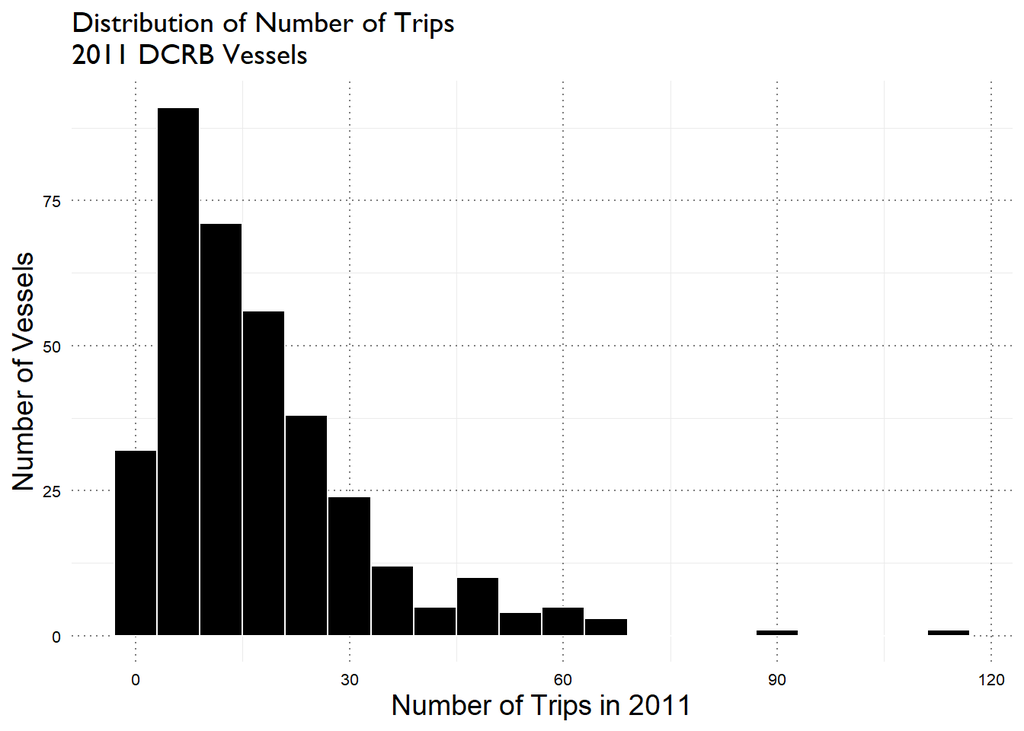

```r
vms_dcrb <- vms %>%
  filter(TARGET_max=="DCRB")

vms_dcrb_summ <- vms_dcrb %>%
  group_by(DOCNUM) %>%
  summarise(n_trips=n_distinct(Rec_ID),n_vms=n_distinct(VMS_RECNO))

# Distribution of number of trips by vessel
dcrb_trips_plot <- vms_dcrb_summ %>%
  ggplot(aes(n_trips))+
  geom_histogram(bins=20,fill='black',col='white')+
  labs(x='Number of Trips in 2011',y='Number of Vessels',title="Distribution of Number of Trips\n2011 DCRB Vessels")
dcrb_trips_plot
```

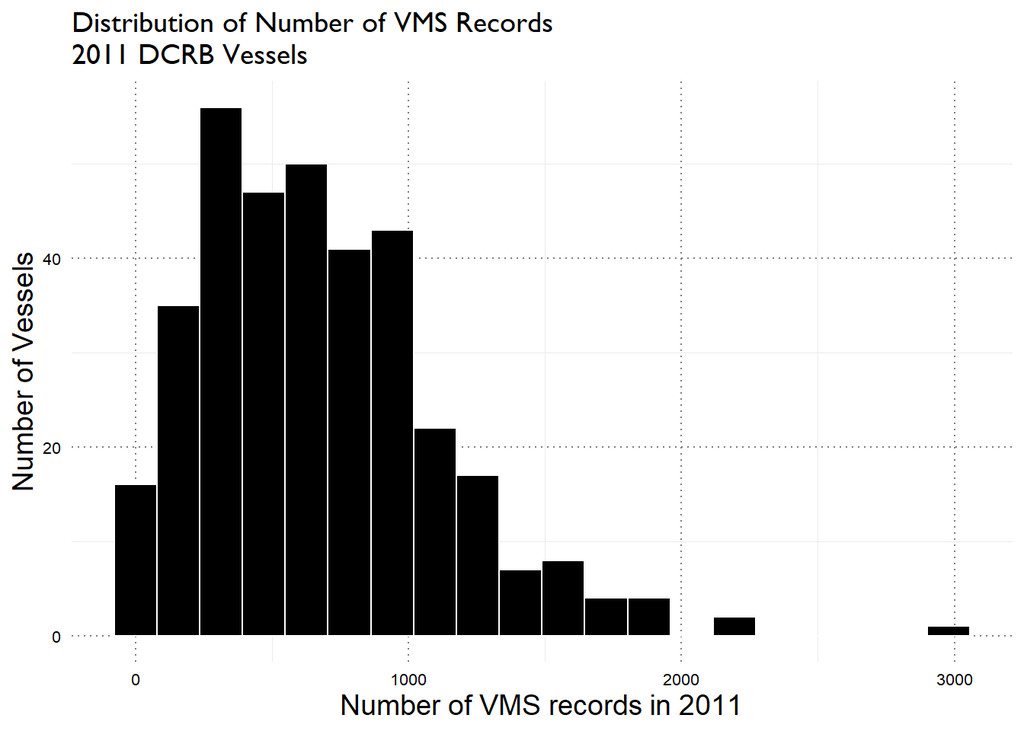

```r
dcrb_vmsrecs_plot <- vms_dcrb_summ %>%
  ggplot(aes(n_vms))+
  geom_histogram(bins=20,fill='black',col='white')+
  labs(x='Number of VMS records in 2011',y='Number of Vessels',title="Distribution of Number of VMS Records\n2011 DCRB Vessels")
dcrb_vmsrecs_plot
```

### Single vs. Multi-target Trips

One of the major choices in the processing of VMS and fish ticket data is figuring out how to deal with the fact that fishers often report or submit multiple fish tickets in one day. We can look at how many vessels this applies to, and how often this is the case for primarily Dungeness trips.

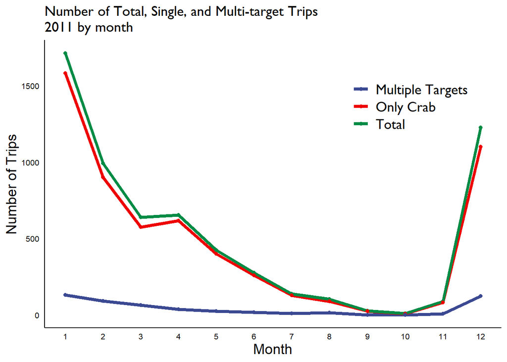

```r
# Count what proportion of DCRB trips are multi-target
dcrb_multi_trips_count <- vms_dcrb %>%
  group_by(Rec_ID) %>%
  slice(1) %>%
  ungroup() %>%
  select(Rec_ID,DOCNUM,TARGET,TARGET_max,westcoastdate_notime) %>%
  mutate(is_multi_trip=ifelse(nchar(TARGET)>4,1,0)) %>%
  # we can count by month
  mutate(month=month(westcoastdate_notime)) %>%
  group_by(month) %>%
  summarise(tot_tix=n_distinct(Rec_ID),n_singletarget_trips=sum(is_multi_trip==0),n_multi_trips=sum(is_multi_trip)) %>%
  ungroup()

dcrb_multi_trips_count %>%
  gather(type,ntrips,tot_tix:n_multi_trips) %>%
  ggplot(aes(month,ntrips,color=type))+
  geom_line(size=1.5)+
  geom_point(size=1.5)+
  scale_x_continuous(breaks=1:12,limits = c(1,12))+
  scale_color_aaas(name="",labels=c("Multiple Targets","Only Crab","Total"))+
  labs(x="Month",y="Number of Trips",title="Number of Total, Single, and Multi-target Trips\n2011 by month")+
  theme(legend.position = c(0.8,0.8),
        panel.grid.major = element_blank(),
        panel.grid.minor = element_blank(),
        axis.line = element_line())
```

### Distribution of Trips

All Dungeness crab VMS records

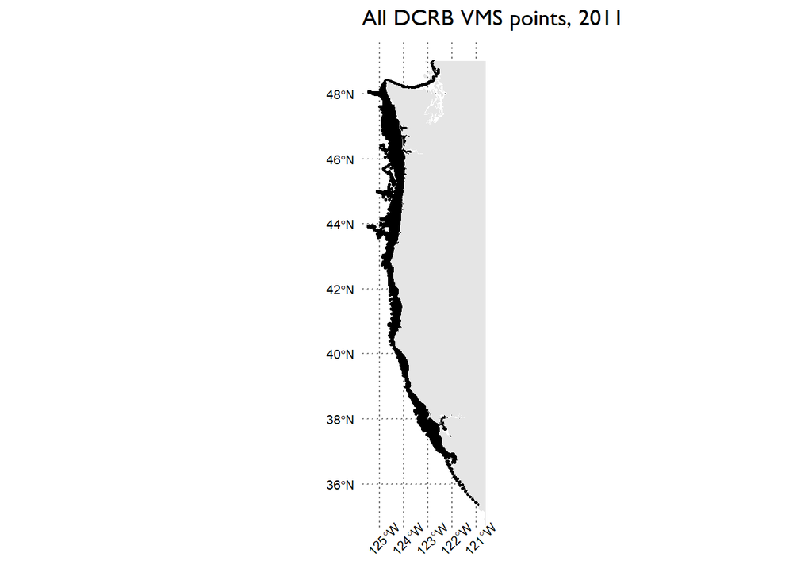

```r
coastline <- ne_states(country='United States of America',returnclass = 'sf') %>%
  filter(name %in% c('California','Oregon','Washington'))

vms_dcrb_sf <- vms_dcrb %>%
  st_as_sf(coords=c('LONGITUDE','LATITUDE'),crs=4326)

bbox <- st_bbox(vms_dcrb_sf)
ggplot()+
  geom_sf(data=vms_dcrb_sf,size=0.5)+
  geom_sf(data=coastline,col=NA)+
  lims(x=c(bbox[1],bbox[3]),y=c(bbox[2],bbox[4]))+
  labs(title="All DCRB VMS points, 2011")+
  theme(axis.text.x = element_text(angle=45))
```

## Representative Vessels

Now we extract a vessel and look at its tracks

```r
# fishtix <- read_csv("C:/Users/owenr/Documents/postdocs/NOAA NRC/NWFSC work/VMS DATA CONFIDENTIAL/Processed Data/VMS/VMS_Outputs_wTARGET_10d_lookback_2011_final_cleaned_interpolated_regular.csv")

# For now, just look at a vessel with many VMS records
# somewhat haphazardly, I choose vessel "605198", which had 31 trips and >2000 VMS pings in 2011
sample_vessel_vms <- vms_dcrb %>%
  filter(DOCNUM=="605198")
```

For this vessel, how many VMS points are associated with each trip?

```r
sample_vessel_vms %>%
  count(Rec_ID) %>%
  arrange(desc(n)) %>%
  kable(col.names = c("Fish Ticket","Number of VMS"))
```

| Fish Ticket | Number of VMS |
| --- | --- |
| 441484781 | 204 |
| 441412153 | 203 |
| 441438009 | 156 |
| 441457492 | 114 |
| 441431041 | 109 |
| 441409503 | 108 |
| 441431613 | 108 |
| 441457540 | 91 |
| 48333981 | 85 |
| 441495315 | 85 |
| 48332375 | 80 |
| 441493567 | 79 |
| 48333969 | 67 |
| 441419977 | 64 |
| 441441150 | 64 |
| 441435321 | 63 |
| 441496721 | 61 |
| 48333747 | 58 |
| 441436021 | 58 |
| 48333757 | 43 |
| 441504045 | 39 |
| 441431427 | 35 |
| 441508946 | 33 |
| 48330793 | 21 |
| 441451659 | 19 |
| 441428435 | 16 |
| 441462877 | 16 |
| 441460532 | 13 |
| 441489138 | 13 |
| 441435446 | 11 |
| 441491906 | 11 |

The vessel’s trips ranged between 11 and 204 interpolated VMS points.

The shortest trip (by number of VMS pings) looked like this:

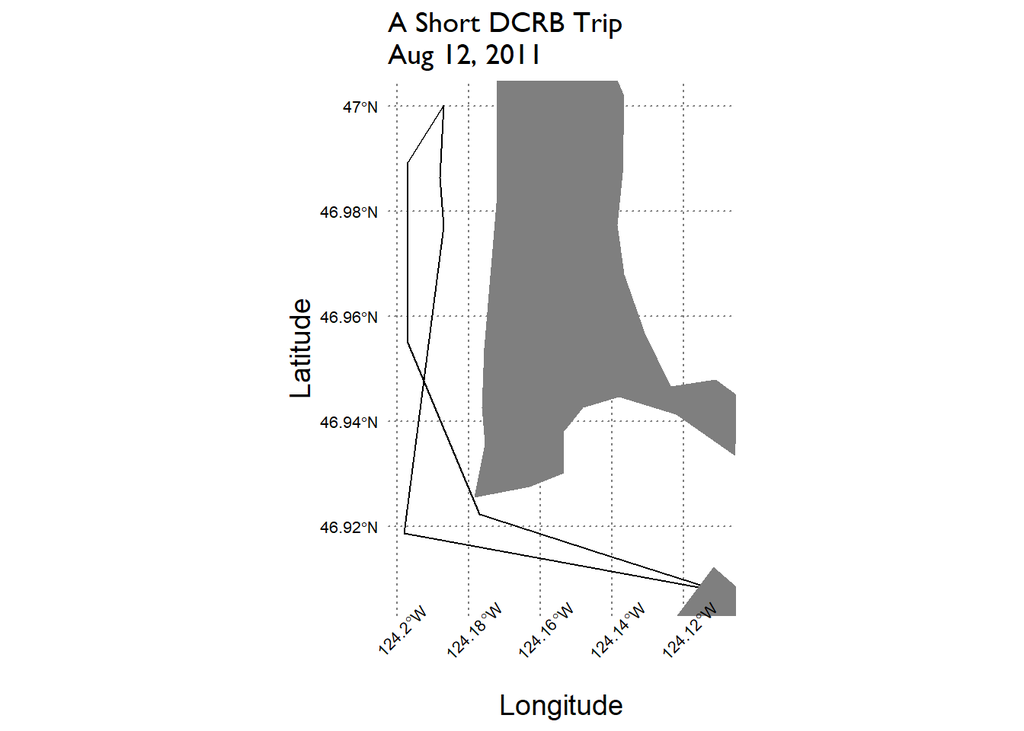

```r
short_trip<-sample_vessel_vms %>%
  filter(Rec_ID==441491906) %>%
  st_as_sf(coords=c("LONGITUDE","LATITUDE"),crs=4326)

bbox_trip1 <- st_bbox(short_trip)

# sptable for drawing paths
short_trip_tbl <- short_trip %>%
  spbabel::sptable()

ggplot()+
  geom_path(data=short_trip_tbl,aes(x_,y_),color="black")+
  geom_sf(data=coastline,col=NA,fill='gray50')+
  lims(x=c(bbox_trip1[1],bbox_trip1[3]),y=c(bbox_trip1[2],bbox_trip1[4]))+
  theme(axis.text.x = element_text(angle=45))+
  labs(x="Longitude",y="Latitude",title="A Short DCRB Trip\nAug 12, 2011")
```

While the longest looked like this:

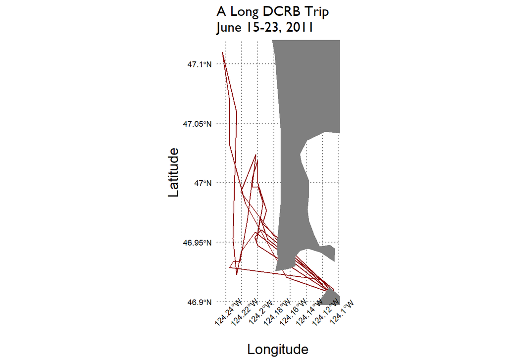

```r
long_trip<-sample_vessel_vms %>%
  filter(Rec_ID==441484781) %>%
  st_as_sf(coords=c("LONGITUDE","LATITUDE"),crs=4326)

bbox_trip2 <- st_bbox(long_trip)

# sptable for drawing paths
long_trip_tbl <- long_trip %>%
  spbabel::sptable()

ggplot()+
  geom_path(data=long_trip_tbl,aes(x_,y_),color="darkred")+
  geom_sf(data=coastline,col=NA, fill='gray50')+
  lims(x=c(bbox_trip2[1],bbox_trip2[3]),y=c(bbox_trip2[2],bbox_trip2[4]))+
  theme(axis.text.x = element_text(angle=45))+
  labs(x="Longitude",y="Latitude",title="A Long DCRB Trip\nJune 15-23, 2011")
```